# Instacart EDA

Mark Rossi

June 28, 2017

### Hello! This notebook is an initial exploratory analysis to support the Instacart Basket Challenge.

Instacart combines a grocery-ordering app with a delivery service: users select products on the application, then personal shoppers do the shopping and deliver it to their doorstep.

The underlying data science supporting this service uses transactional data to provide recommendations to a user along the way during their session.

For this challenge specifically, the task is to predict which previously purchased products will be in a user’s next order.

### Import libraries & get our data

```r
library(data.table)
library(dplyr)
library(ggplot2)
library(knitr)
library(stringr)
library(DT)

orders <- fread('Data/orders.csv')
products <- fread('Data/products.csv')
order_products <- fread('Data/order_products__train.csv')
order_products_prior <- fread('Data/order_products__prior.csv')
aisles <- fread('Data/aisles.csv')
departments <- fread('Data/departments.csv')
```

### Data

#### orders

```r
kable(head(orders, 12))
```

| order_id | user_id | eval_set | order_number | order_dow | order_hour_of_day | days_since_prior_order |
| --- | --- | --- | --- | --- | --- | --- |
| 2539329 | 1 | prior | 1 | 2 | 8 | NA |
| 2398795 | 1 | prior | 2 | 3 | 7 | 15 |
| 473747 | 1 | prior | 3 | 3 | 12 | 21 |
| 2254736 | 1 | prior | 4 | 4 | 7 | 29 |
| 431534 | 1 | prior | 5 | 4 | 15 | 28 |
| 3367565 | 1 | prior | 6 | 2 | 7 | 19 |
| 550135 | 1 | prior | 7 | 1 | 9 | 20 |
| 3108588 | 1 | prior | 8 | 1 | 14 | 14 |
| 2295261 | 1 | prior | 9 | 1 | 16 | 0 |
| 2550362 | 1 | prior | 10 | 4 | 8 | 30 |
| 1187899 | 1 | train | 11 | 4 | 8 | 14 |
| 2168274 | 2 | prior | 1 | 2 | 11 | NA |

```r
glimpse(orders)
```

```
## Observations: 3,421,083
## Variables: 7
## $ order_id               <int> 2539329, 2398795, 473747, 2254736, 4315...
## $ user_id                <int> 1, 1, 1, 1, 1, 1, 1, 1, 1, 1, 1, 2, 2, ...
## $ eval_set               <chr> "prior", "prior", "prior", "prior", "pr...
## $ order_number           <int> 1, 2, 3, 4, 5, 6, 7, 8, 9, 10, 11, 1, 2...
## $ order_dow              <int> 2, 3, 3, 4, 4, 2, 1, 1, 1, 4, 4, 2, 5, ...
## $ order_hour_of_day      <int> 8, 7, 12, 7, 15, 7, 9, 14, 16, 8, 8, 11...
## $ days_since_prior_order <dbl> NA, 15, 21, 29, 28, 19, 20, 14, 0, 30, ...
```

#### order_products_train

```r
kable(head(order_products, 12))
```

| order_id | product_id | add_to_cart_order | reordered |
| --- | --- | --- | --- |
| 1 | 49302 | 1 | 1 |
| 1 | 11109 | 2 | 1 |
| 1 | 10246 | 3 | 0 |
| 1 | 49683 | 4 | 0 |
| 1 | 43633 | 5 | 1 |
| 1 | 13176 | 6 | 0 |
| 1 | 47209 | 7 | 0 |
| 1 | 22035 | 8 | 1 |
| 36 | 39612 | 1 | 0 |
| 36 | 19660 | 2 | 1 |
| 36 | 49235 | 3 | 0 |
| 36 | 43086 | 4 | 1 |

```r
glimpse(order_products)
```

```
## Observations: 1,384,617
## Variables: 4
## $ order_id          <int> 1, 1, 1, 1, 1, 1, 1, 1, 36, 36, 36, 36, 36, ...
## $ product_id        <int> 49302, 11109, 10246, 49683, 43633, 13176, 47...
## $ add_to_cart_order <int> 1, 2, 3, 4, 5, 6, 7, 8, 1, 2, 3, 4, 5, 6, 7,...
## $ reordered         <int> 1, 1, 0, 0, 1, 0, 0, 1, 0, 1, 0, 1, 1, 1, 1,...
```

#### products

```r
kable(head(products, 12))
```

| product_id | product_name | aisle_id | department_id |
| --- | --- | --- | --- |
| 1 | Chocolate Sandwich Cookies | 61 | 19 |
| 2 | All-Seasons Salt | 104 | 13 |
| 3 | Robust Golden Unsweetened Oolong Tea | 94 | 7 |
| 4 | Smart Ones Classic Favorites Mini Rigatoni With Vodka Cream Sauce | 38 | 1 |
| 5 | Green Chile Anytime Sauce | 5 | 13 |
| 6 | Dry Nose Oil | 11 | 11 |
| 7 | Pure Coconut Water With Orange | 98 | 7 |
| 8 | Cut Russet Potatoes Steam N’ Mash | 116 | 1 |
| 9 | Light Strawberry Blueberry Yogurt | 120 | 16 |
| 10 | Sparkling Orange Juice & Prickly Pear Beverage | 115 | 7 |
| 11 | Peach Mango Juice | 31 | 7 |
| 12 | Chocolate Fudge Layer Cake | 119 | 1 |

```r
glimpse(products)
```

```
## Observations: 49,688
## Variables: 4
## $ product_id    <int> 1, 2, 3, 4, 5, 6, 7, 8, 9, 10, 11, 12, 13, 14, 1...
## $ product_name  <chr> "Chocolate Sandwich Cookies", "All-Seasons Salt"...
## $ aisle_id      <int> 61, 104, 94, 38, 5, 11, 98, 116, 120, 115, 31, 1...
## $ department_id <int> 19, 13, 7, 1, 13, 11, 7, 1, 16, 7, 7, 1, 11, 17,...
```

#### order_products_prior

```r
kable(head(order_products_prior, 12))
```

| order_id | product_id | add_to_cart_order | reordered |
| --- | --- | --- | --- |
| 2 | 33120 | 1 | 1 |
| 2 | 28985 | 2 | 1 |
| 2 | 9327 | 3 | 0 |
| 2 | 45918 | 4 | 1 |
| 2 | 30035 | 5 | 0 |
| 2 | 17794 | 6 | 1 |
| 2 | 40141 | 7 | 1 |
| 2 | 1819 | 8 | 1 |
| 2 | 43668 | 9 | 0 |
| 3 | 33754 | 1 | 1 |
| 3 | 24838 | 2 | 1 |
| 3 | 17704 | 3 | 1 |

```r
glimpse(order_products_prior)
```

```
## Observations: 32,434,489
## Variables: 4
## $ order_id          <int> 2, 2, 2, 2, 2, 2, 2, 2, 2, 3, 3, 3, 3, 3, 3,...
## $ product_id        <int> 33120, 28985, 9327, 45918, 30035, 17794, 401...
## $ add_to_cart_order <int> 1, 2, 3, 4, 5, 6, 7, 8, 9, 1, 2, 3, 4, 5, 6,...
## $ reordered         <int> 1, 1, 0, 1, 0, 1, 1, 1, 0, 1, 1, 1, 1, 1, 1,...
```

#### aisles

```r
kable(head(aisles, 12))
```

| aisle_id | aisle |
| --- | --- |
| 1 | prepared soups salads |
| 2 | specialty cheeses |
| 3 | energy granola bars |
| 4 | instant foods |
| 5 | marinades meat preparation |
| 6 | other |
| 7 | packaged meat |
| 8 | bakery desserts |
| 9 | pasta sauce |
| 10 | kitchen supplies |
| 11 | cold flu allergy |
| 12 | fresh pasta |

```r
glimpse(aisles)
```

```
## Observations: 134
## Variables: 2
## $ aisle_id <int> 1, 2, 3, 4, 5, 6, 7, 8, 9, 10, 11, 12, 13, 14, 15, 16...
## $ aisle    <chr> "prepared soups salads", "specialty cheeses", "energy...
```

#### departments

```r
kable(head(departments, 12))
```

| department_id | department |
| --- | --- |
| 1 | frozen |
| 2 | other |
| 3 | bakery |
| 4 | produce |
| 5 | alcohol |
| 6 | international |
| 7 | beverages |
| 8 | pets |
| 9 | dry goods pasta |
| 10 | bulk |
| 11 | personal care |
| 12 | meat seafood |

```r
glimpse(departments)
```

```
## Observations: 21
## Variables: 2
## $ department_id <int> 1, 2, 3, 4, 5, 6, 7, 8, 9, 10, 11, 12, 13, 14, 1...
## $ department    <chr> "frozen", "other", "bakery", "produce", "alcohol...
```

### Some basic recoding:

```r
# orders: make sure hour of day and is numeric and eval_set is made a factor
orders <- orders %>% mutate(order_hour_of_day = as.numeric(order_hour_of_day), eval_set = as.factor(eval_set))

# products: set product_name to factor
products <- products %>% mutate(product_name = as.factor(product_name))

# same for names of aisles & departments
aisles <- aisles %>% mutate(aisle = as.factor(aisle))
departments <- departments %>% mutate(department = as.factor(department))
```

### Let’s look at the orders themselves first…

#### Hour of day

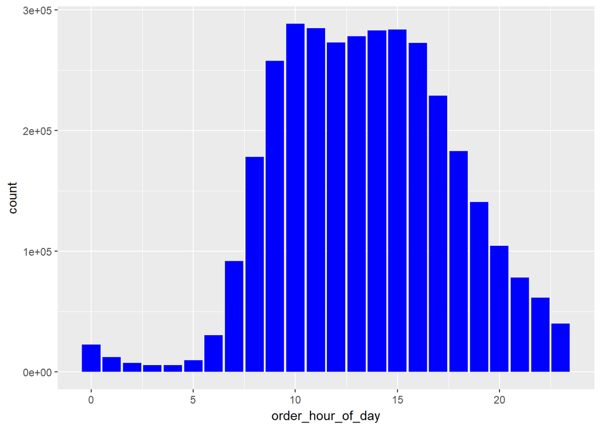

```r
orders %>%
  ggplot(aes(x=order_hour_of_day)) +
  geom_histogram(stat="count",fill="blue")
```

#### Day of week

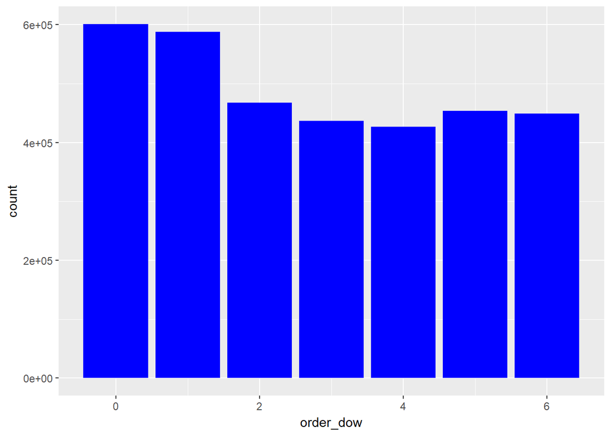

```r
orders %>%
  ggplot(aes(x=order_dow)) +
  geom_histogram(stat="count",fill="blue")
```

#### How do DOW/hour of day compare?

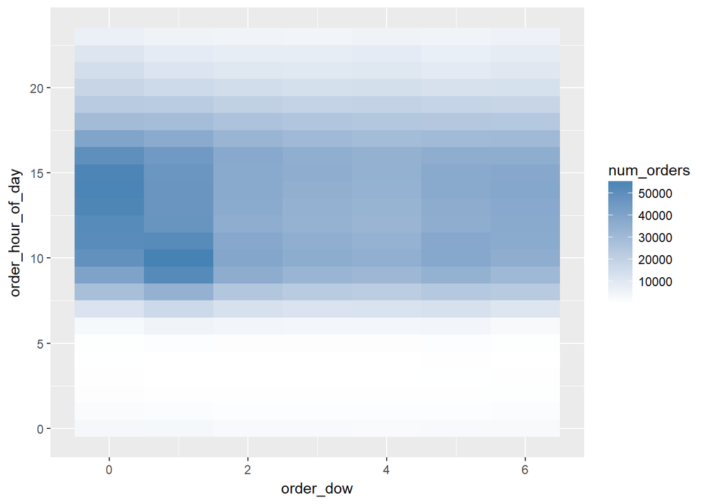

```r
orders %>%
  group_by(order_dow, order_hour_of_day) %>%
  summarize(num_orders = n()) %>%
  ggplot(aes(order_dow, order_hour_of_day)) +
  geom_tile(aes(fill=num_orders)) +
  scale_fill_continuous(low="white", high="steelblue")
```

#### Typical # days between orders?

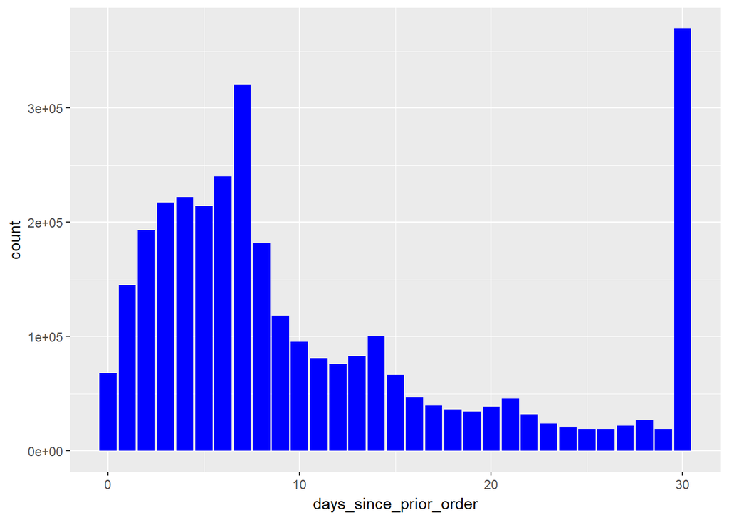

```r
orders %>%
  ggplot(aes(x=days_since_prior_order)) +
  geom_histogram(stat="count", fill="blue")
```

#### How many prior orders are there?

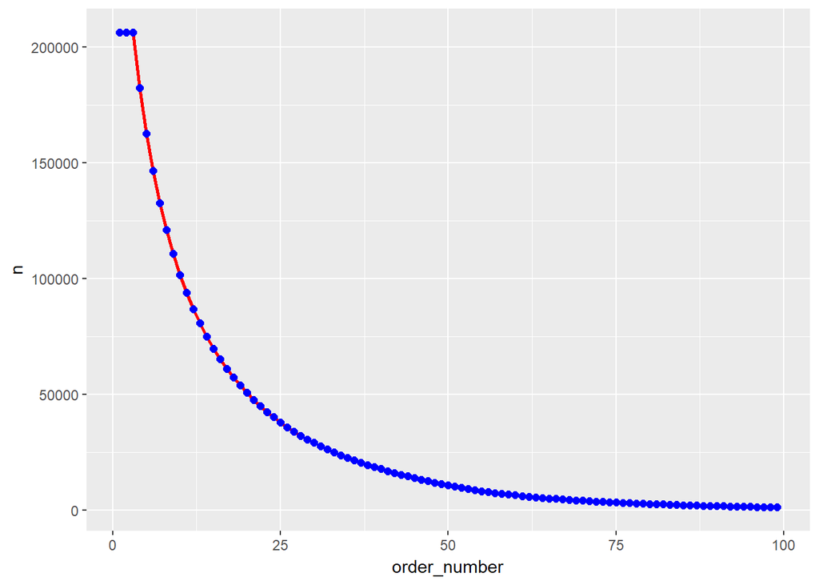

```r
orders %>% filter(eval_set=="prior") %>% count(order_number) %>% ggplot(aes(x=order_number, y=n)) + geom_line(color="red", size=1) + geom_point(size=2, color="blue")
```

### How many items do people buy?

#### Training set

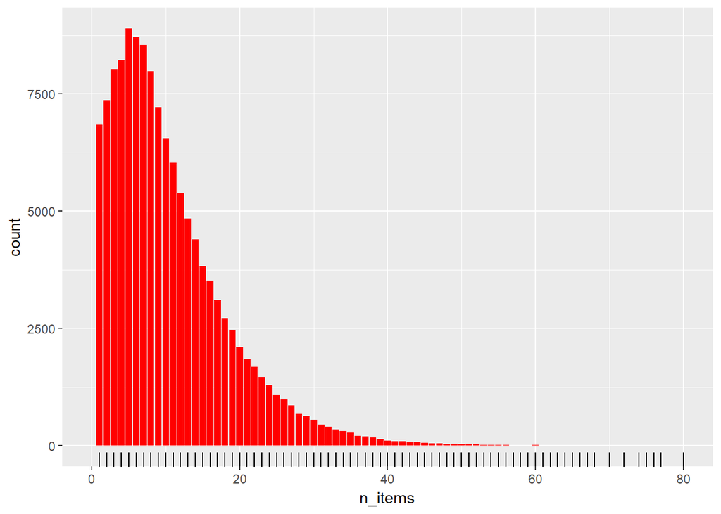

```r
order_products %>%
  group_by(order_id) %>%
  summarize(n_items = last(add_to_cart_order)) %>%
  ggplot(aes(x=n_items)) +
  geom_histogram(stat="count", fill="red") +
  geom_rug() +
  coord_cartesian(xlim=c(0,80))
```

#### Prior orders set

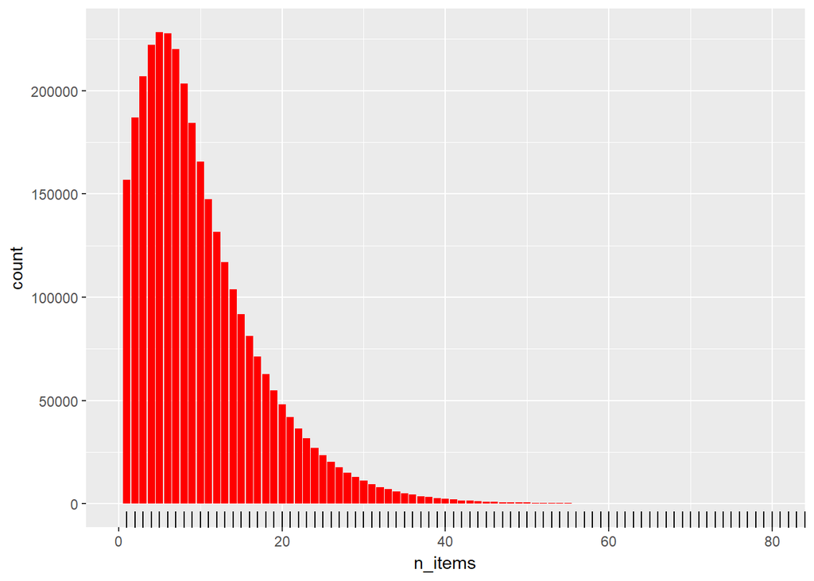

```r
order_products_prior %>%
  group_by(order_id) %>%
  summarize(n_items = last(add_to_cart_order)) %>%
  ggplot(aes(x=n_items)) +
  geom_histogram(stat="count", fill="red") +
  geom_rug() +
  coord_cartesian(xlim=c(0,80))
```

### Looking more closely now at the items themselves…

#### What are the 10 most popular items on the site?

```r
tmp <- order_products %>%
  group_by(product_id) %>%
             summarize(count = n()) %>%
             top_n(10, wt=count) %>%
             left_join(select(products, product_id, product_name), by="product_id") %>%
                         arrange(desc(count))

kable(tmp)
```

| product_id | count | product_name |
| --- | --- | --- |
| 24852 | 18726 | Banana |
| 13176 | 15480 | Bag of Organic Bananas |
| 21137 | 10894 | Organic Strawberries |
| 21903 | 9784 | Organic Baby Spinach |
| 47626 | 8135 | Large Lemon |
| 47766 | 7409 | Organic Avocado |
| 47209 | 7293 | Organic Hass Avocado |
| 16797 | 6494 | Strawberries |
| 26209 | 6033 | Limes |
| 27966 | 5546 | Organic Raspberries |

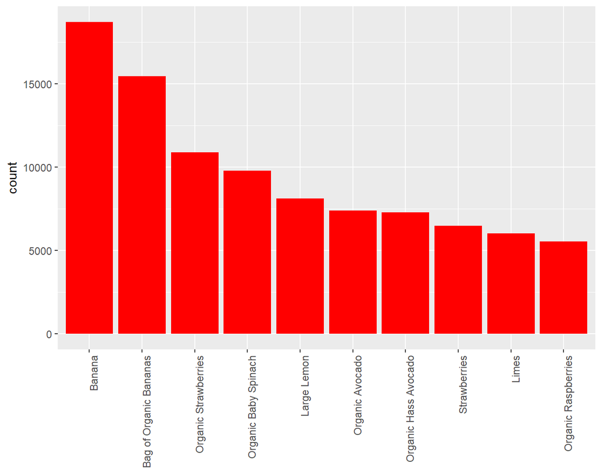

```r
tmp %>%
  ggplot(aes(x=reorder(product_name,-count), y=count))+
  geom_bar(stat="identity",fill="red")+
  theme(axis.text.x=element_text(angle=90, hjust=1),axis.title.x = element_blank())
```

### What about reorders?

#### How often is an item a reorder versus a ‘fresh’ one?

```r
tmp <- order_products %>%
  group_by(reordered) %>%
  summarize(count = n()) %>%
  mutate(reordered = as.factor(reordered)) %>%
  mutate(proportion = count/sum(count))

kable(tmp)
```

| reordered | count | proportion |
| --- | --- | --- |
| 0 | 555793 | 0.4014056 |
| 1 | 828824 | 0.5985944 |

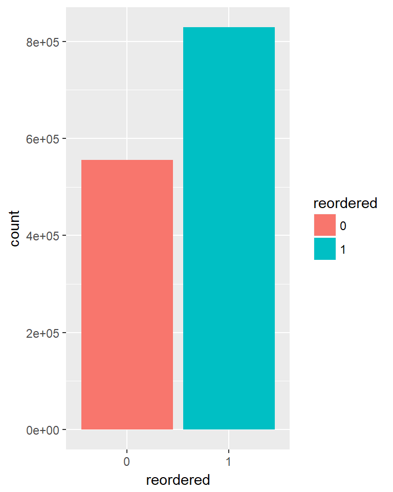

```r
tmp %>%
  ggplot(aes(x=reordered, y=count, fill=reordered)) +
  geom_bar(stat="identity")
```

#### For individual orders, what is a typical ratio of reordered items to new ones?

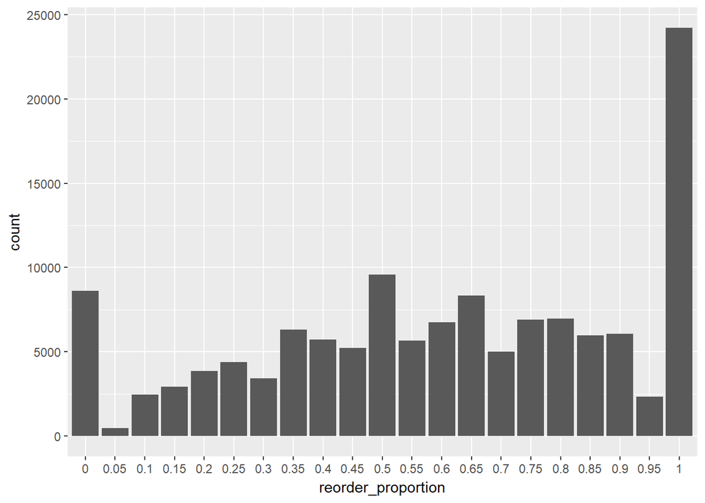

```r
order_products %>% group_by(order_id) %>% summarize(reorder_proportion = round((sum(reordered) / n()) / 0.05) * 0.05) %>% mutate(reorder_proportion = as.factor(reorder_proportion)) %>% ggplot(aes(x=reorder_proportion)) + geom_histogram(stat="count")
```

#### Which items are REordered the most?

```r
tmp <-order_products %>%
  group_by(product_id) %>%
  summarize(proportion_reordered = mean(reordered), n=n()) %>%
  filter(n>40) %>%
  top_n(20,wt=proportion_reordered) %>%
  arrange(desc(proportion_reordered)) %>%
  left_join(products,by="product_id")

kable(tmp)
```

| product_id | proportion_reordered | n | product_name | aisle_id | department_id |
| --- | --- | --- | --- | --- | --- |
| 1729 | 0.9347826 | 92 | 2% Lactose Free Milk | 84 | 16 |
| 20940 | 0.9130435 | 368 | Organic Low Fat Milk | 84 | 16 |
| 12193 | 0.8983051 | 59 | 100% Florida Orange Juice | 98 | 7 |
| 21038 | 0.8888889 | 81 | Organic Spelt Tortillas | 128 | 3 |
| 31764 | 0.8888889 | 45 | Original Sparkling Seltzer Water Cans | 115 | 7 |
| 24852 | 0.8841717 | 18726 | Banana | 24 | 4 |
| 117 | 0.8833333 | 120 | Petit Suisse Fruit | 2 | 16 |
| 39180 | 0.8819876 | 483 | Organic Lowfat 1% Milk | 84 | 16 |
| 12384 | 0.8810409 | 269 | Organic Lactose Free 1% Lowfat Milk | 91 | 16 |
| 24024 | 0.8785249 | 461 | 1% Lowfat Milk | 84 | 16 |
| 36717 | 0.8765432 | 81 | Double Fiber Bread | 112 | 3 |
| 38689 | 0.8756219 | 1206 | Organic Reduced Fat Milk | 84 | 16 |
| 9810 | 0.8734177 | 79 | 100% Lactose Free 1% Lowfat Milk | 91 | 16 |
| 5514 | 0.8720000 | 125 | Organic Homogenized Whole Milk | 84 | 16 |
| 23383 | 0.8695652 | 69 | Super Natural Organic Whole Milk | 84 | 16 |
| 36011 | 0.8692972 | 811 | Organic Fat Free Milk | 84 | 16 |
| 29447 | 0.8688811 | 572 | Milk, Organic, Vitamin D | 84 | 16 |
| 22610 | 0.8688525 | 122 | Reduced Fat 2% Lactose-Free Milk | 91 | 16 |
| 43394 | 0.8641509 | 265 | Organic Lactose Free Whole Milk | 91 | 16 |
| 44799 | 0.8639798 | 397 | Fresh CA Grown Eggs | 86 | 16 |

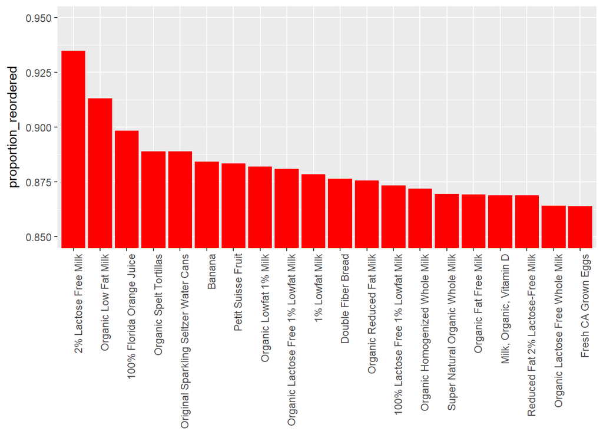

```r
tmp %>%
  ggplot(aes(x=reorder(product_name,-proportion_reordered), y=proportion_reordered))+
  geom_bar(stat="identity",fill="red")+
  theme(axis.text.x=element_text(angle=90, hjust=1),axis.title.x = element_blank())+coord_cartesian(ylim=c(0.85,0.95))
```

#### At what point in the shopping process do people typically add reordered items to their carts?

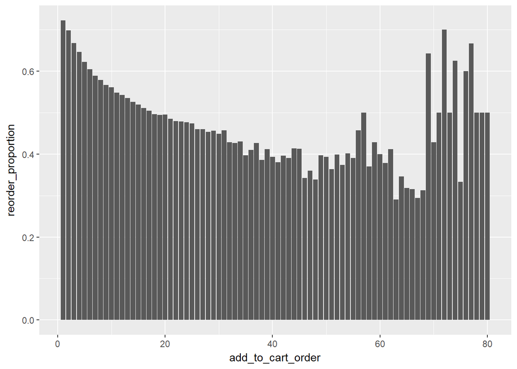

```r
order_products %>% group_by(add_to_cart_order) %>% summarize(reorder_proportion = sum(reordered) / n()) %>% ggplot(aes(x=add_to_cart_order, y=reorder_proportion)) + geom_bar(stat="identity")
```

#### Which items do users put into their carts first?

```r
tmp <- order_products %>%
  group_by(product_id, add_to_cart_order) %>%
  summarize(count = n()) %>% mutate(pct=count/sum(count)) %>%
  filter(add_to_cart_order == 1, count > 10) %>%
  arrange(desc(pct)) %>%
  left_join(products, by="product_id") %>%
  select(product_name, pct, count) %>%
  ungroup() %>%
  top_n(10, wt=pct)
kable(tmp)
```

| product_id | product_name | pct | count |
| --- | --- | --- | --- |
| 45004 | White Multifold Towels | 0.6610169 | 39 |
| 11885 | Sparkling Water, Bottles | 0.5942029 | 41 |
| 13128 | Purified Alkalkine Water with Minerals pH10 | 0.5714286 | 12 |
| 4100 | Organic Dark Roast | 0.5600000 | 14 |
| 1729 | 2% Lactose Free Milk | 0.5217391 | 48 |
| 6729 | Cookie Tray | 0.4861111 | 35 |
| 9285 | Boneless Pork Shoulder Butt | 0.4814815 | 13 |
| 6848 | Party Tumblers | 0.4615385 | 12 |
| 12640 | Sport Bottle with Flip Cap Natural Spring Water | 0.4615385 | 12 |
| 26405 | XL Pick-A-Size Paper Towel Rolls | 0.4476190 | 47 |

#### Is there a relationship between days since last order and reordering?

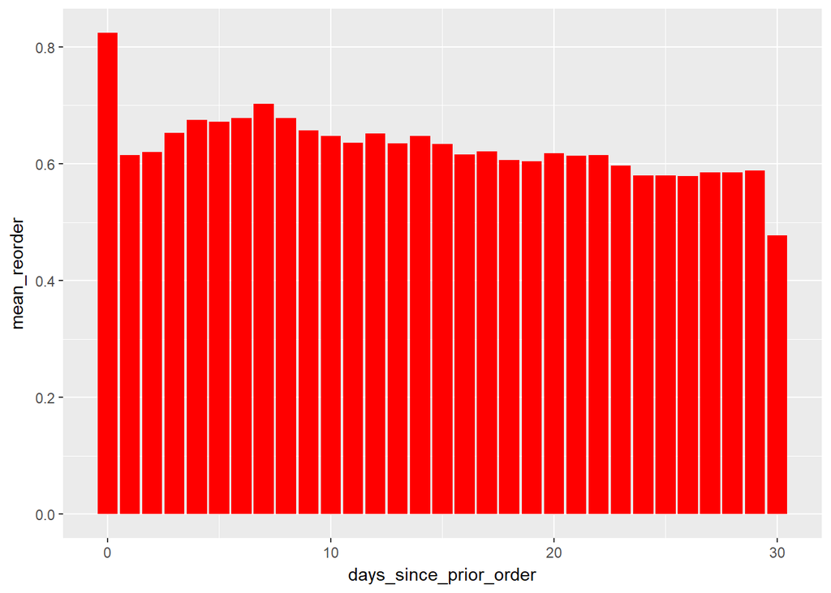

```r
order_products %>%
  left_join(orders, by="order_id") %>%
  group_by(days_since_prior_order) %>%
  summarize(mean_reorder = mean(reordered)) %>%
  ggplot(aes(x=days_since_prior_order, y=mean_reorder)) +
  geom_bar(stat="identity", fill="red")
```

#### Organic vs. Non-organic

```r
products <- products %>% mutate(organic=ifelse(str_detect(products$product_name, 'Organic'), "organic", "non organic"), organic=as.factor(organic))

tmp <- order_products %>%
  left_join(products, by="product_id") %>%
  group_by(organic) %>%
  summarize(count = n()) %>%
  mutate(proportion = count/sum(count))

kable(tmp)
```

| organic | count | proportion |
| --- | --- | --- |
| non organic | 979021 | 0.7070699 |
| organic | 405596 | 0.2929301 |

There are substantially less organic items than non-organic

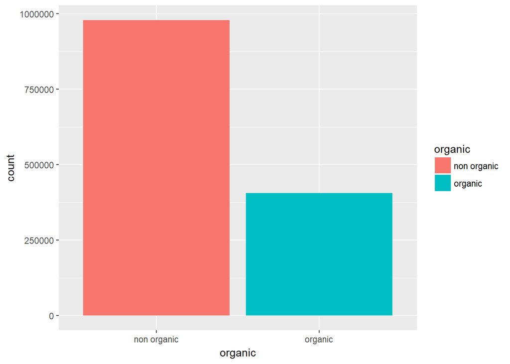

```r
tmp %>%
  ggplot(aes(x=organic, y=count, fill=organic)) +
  geom_bar(stat="identity")
```

However, it looks like the organic items are, on average, reordered more often than others

```r
tmp <- order_products %>% left_join(products, by="product_id") %>%
  group_by(organic) %>%
  summarize(mean_reordered = mean(reordered))

kable(tmp)
```

| organic | mean_reordered |
| --- | --- |
| non organic | 0.5784963 |
| organic | 0.6471070 |

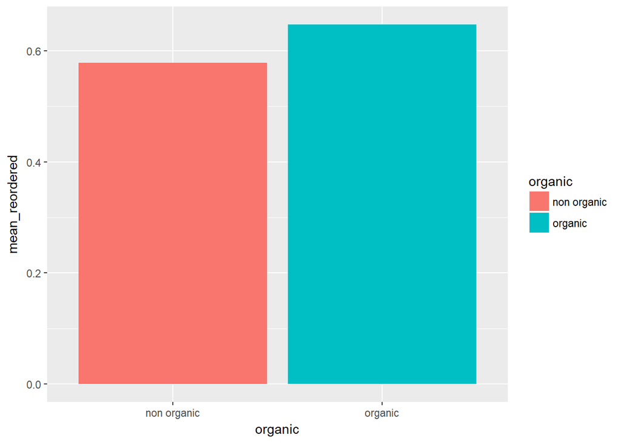

```r
tmp %>%
  ggplot(aes(x=organic, y=mean_reordered, fill=organic)) +
  geom_bar(stat="identity")
```

#### Let’s take a deeper dive into the products themselves